← BlogJieming Li

On this page

Research notebook · 研究笔记

# 视频基模的 Scaling Law：原图存档与补充笔记

这份笔记围绕一个实际问题：**在固定训练预算下，模型参数、数据、多长的视频和多高的分辨率应该怎样配，才能得到对目标任务最有用的模型？**

资料来自《视频基模的 scaling law study》截图，文件署名为“笨笨长不大”。本次收到原编号 **2–18，共 17 张**，全部按顺序保存在文末。图片的完整 JPEG 数据直接嵌入此 Markdown，不依赖 Downloads 中的原文件，也不依赖图片服务器。原图保留原文；正文是整理、推导和补充，修正之处单独说明。

部分 Markdown 阅读器会屏蔽 Base64 图片，显示空白并不代表数据丢失。同目录提供独立 HTML 阅读版，可用浏览器离线查看全部原图；HTML 中公式保留可读的 TeX 源码。两份文件各自包含完整图片，无须随附图片文件夹。

## 1. Scaling law 的产物应该是一项决策

“模型越大越好”无法直接指导训练。真正要回答的是：同样的钱和时间，训练一个大而欠训练的模型，还是一个小而训练充分的模型？增加视频数量，还是延长每个视频？换更强压缩的 VAE，省下来的计算是否值得损失细节？

可以把目标概括为：

$$\min_{N,D,R,F,\eta,B,\mathcal M}\;
L_{\mathrm{eval}}
\quad\text{s.t.}\quad C_{\mathrm{train}}\le C_0.$$

这里 $N$ 是参数量，$D$ 是训练暴露量，$R$ 是分辨率，$F$ 是帧数，$\eta$ 是学习率，$B$ 是 batch size，$\mathcal M$ 表示数据混合等配置。这是整理问题的表达式，不是假设这些量已经有一套通用解析规律。

截图提出的五类用途很实用：分配算力、预测大训练结果、比较不同方法随规模的收益、设计数据策略、迁移超参数。拟合曲线只是实现这些用途的工具。

一个补充是：预测最终 loss 与预测训练中途轨迹是不同任务。若只拟合终点，就不能把中途偏离终点曲线直接判定为训练故障；需要另外建立学习曲线及容许波动范围。

## 2. 先约定 N、D、C，否则比较很容易失真

| 符号或计量项 | 建议记录什么 | 常见混淆 |
| --- | --- | --- |
| 参数量 $N$ | 主干可训练参数、总参数，以及冻结模块参数 | 参数相同但宽深比、注意力结构不同 |
| 独立数据量 $U$ | 去重视频数、独立来源、有效时长 | 同源裁剪被当成全新视频 |
| 训练暴露量 $D$ | 模型实际处理的 token 总数，含重复 | 多跑 epoch 被写成收集更多数据 |
| 单样本序列长 $S$ | VAE 压缩并 patchify 后送入 DiT 的 token 数 | latent 网格位置与 DiT token 混为一谈 |
| 理论训练算力 $C$ | 前向、反向的 FLOPs 及计算约定 | GPU 峰值乘时间被当成有效模型计算 |
| 实际资源 | GPU-hours、墙钟时间、吞吐和费用 | FLOPs 相同就被认为训练时间相同 |

对固定长度样本，处理 $M$ 次样本可写成 $D=MS$。若长度不同，则是 $D=\sum_j S_j$。这个总数适合记账，却没有保存序列长度的分布，也没有说明训练看到了多少独立事件。

截图建议统一用非 embedding 参数，这是一个可选统计口径。更普遍的要求是明确口径并始终一致，同时按实际参与计算的模块核算 FLOPs。视频模型中的 patch embedding、条件投影、文本编码器和 VAE 也要分别说明。

## 3. 为什么先固定 tokenizer 和 loss 定义？

latent diffusion 或 latent flow matching 在 VAE 表示空间里计算损失。更换 VAE 可能改变通道数、压缩率、latent 尺度和信息保留程度。此时，MSE 数值变小，不一定是生成质量变好。

一个简单例子：在预测目标和误差都整体缩放 $s$ 倍的情况下，MSE 变成原来的 $s^2$ 倍。因此数值尺度本身就能制造“改进”。实际扩散任务中，缩放还会影响信噪比，问题更复杂。

固定的应包括：VAE checkpoint、latent 归一化、噪声日程、预测目标、时间采样分布、损失权重，以及按 token、通道还是样本求平均的方式。改变其中一项，应建立单独曲线或明确将其作为实验变量。

这不等于不同 tokenizer 永远不能比较。正确做法是分别研究其训练效率，再在共同的输出空间和目标任务上比较，比如重建细节、运动连续性、生成质量和机器人任务表现。它们构成的是不同配置的性能—成本边界，而不是一条未经校准的 latent-loss 曲线。

## 4. 从一段视频算出 DiT token 数

设输入有 $F$ 帧，分辨率为 $H\times W$，VAE 在时间和空间上的压缩率分别为 $r_t,r_h,r_w$，DiT patch 大小为 $p_t,p_h,p_w$。忽略边界取整时：

$$S\approx
\frac{F}{r_tp_t}
\frac{H}{r_hp_h}
\frac{W}{r_wp_w}.$$

实际实现可能对首帧特殊处理。例如某些因果视频 VAE 使用 $(F-1)/r_t+1$ 的时间长度规则，所以 81 帧在 4 倍时间压缩下得到 21 个 latent 时间位置。

按截图的假设：81 帧、480×832、时间压缩 4、空间压缩 8、空间 patch 2、时间 patch 1，则：

$$S=21\times30\times52=32760.$$

若明确选用 720×1280，其他设置不变，则：

$$S=21\times45\times80=75600.$$

所以从这个 480p 设置到这个 720p 设置，序列长增加约 2.31 倍。这里同时略改了宽高比，因此不是严格同宽高比缩放。

更高帧率、更长片段、更高分辨率都能增加 $S$，但增加的信息不同。固定时长提高帧率，可能看到更细的运动；固定帧数提高帧率，反而缩短覆盖的事件时间。实验必须同时记录帧数、帧率和真实时长。

## 5. 6ND 为什么可能低估视频训练成本？

$C\approx6ND$ 主要估计稠密参数矩阵的训练计算。长序列的注意力还要计算 token 两两交互，这部分随 $S^2$ 增长。

下面按一个简化的全注意力 Transformer 自行推导：层数为 $\ell$，宽度为 $d$，MLP 扩张比为 4，乘加计为两个 FLOPs，忽略 softmax、归一化和条件模块。

每层参数约为：

$$N_{\mathrm{layer}}\approx4d^2+8d^2=12d^2.$$

参数矩阵的前向 FLOPs 约为 $24Sd^2$，而 $QK^\top$ 和 $AV$ 两次全注意力乘法合计约为 $4S^2d$。若训练计算粗略取前向三倍：

$$C_{\mathrm{train}}
\approx M\ell(72Sd^2+12S^2d)
=6ND+12\ell SdD.$$

于是该假设下的注意力交互项与参数项之比为：

$$\frac{C_{\mathrm{attn}}}{C_{\mathrm{param}}}
\approx\frac{S}{6d}.$$

截图使用了 $S/(12d)$ 的估算，这能对应 Kaplan 表 1 中每 token 前向 $2N+2\ell Sd$ 的口径。系数会受因果三角计算、全注意力、MLP 结构及计数方式影响，不能将其直接当作所有视频 DiT 的通式。**需要保留的结论是长序列项不能忽略；具体倍数必须按模型计算。** [Kaplan 原文 §2.1](https://arxiv.org/html/2001.08361v1#S2.SS1)

按上述全注意力简化模型，$d=3072$ 时，32760 个 token 的注意力项约为参数项的 1.78 倍，总量约为 $6ND$ 的 2.78 倍；75600 个 token 时分别约为 4.10 倍和 5.10 倍。这些是公式算例，不是实测训练倍数。

使用窗口、稀疏或时空分解注意力后，应重写公式。FlashAttention 改善显存访问和实现效率，也不能简单理解为把精确全注意力的二次交互变成线性 FLOPs。Yin 等的视频 DiT 研究同样把序列长度纳入计算成本分析。[CVPR 2025 原文](https://openaccess.thecvf.com/content/CVPR2025/papers/Yin_Towards_Precise_Scaling_Laws_for_Video_Diffusion_Transformers_CVPR_2025_paper.pdf)

## 6. 相同 token 总数，为什么训练成本仍然不同？

在全注意力下，计算包含 $\sum_j S_j^2$。因此：

$$\sum_j S_j\ \text{相同}
\quad\not\Rightarrow\quad
\sum_j S_j^2\ \text{相同}.$$

例如两个长度为 $S$ 的片段，共有 $2S$ 个 token，注意力项正比于 $2S^2$；一个长度为 $2S$ 的片段，token 总数仍是 $2S$，注意力项却正比于 $4S^2$。

长片段多花的计算可能换来跨时间交互能力，但这要由任务验证。对接触事件预测，关键可能是事件是否完整覆盖；对高速运动，关键可能是帧率；对精细操作，关键可能是手指与物体接触区域的空间细节。

所以视频 scaling 不能只记录 $N,D$。至少应保留序列长度分布、分辨率与时长分桶，以及各桶实际消耗的 FLOPs。

## 7. 扩散／Flow Matching 的验证 loss 怎样才可比？

一般训练目标可以写为：

$$L=\mathbb E_{x,c,t,\epsilon}
\left[w(t)\|f_\theta(z_t,t,c)-y(x,\epsilon,t)\|^2\right].$$

$t$ 为噪声时间，$\epsilon$ 为随机噪声，$y$ 可能是噪声、速度或其他目标。换目标或权重，就改变了损失的含义。

一个可执行的评估协议是：固定 held-out 视频与文本、固定裁剪和采样位置、固定噪声种子与时间集合；所有 checkpoint 使用同样的组合。这样比较两模型时，随机波动更多地相互抵消。

同时应报告分时间区间的误差，以及按明确权重合成的总损失。均匀取几个 $t$ 的平均，不一定等于训练分布下的期望，需要说明最终估计的是什么。

固定噪声只降低评估噪声，不消除训练随机性。关键配置仍需要不同初始化和数据顺序的重复实验。评估集反复被用于调参后，也应另留最终检查集，防止配置逐渐适应固定噪声样本。

## 8. 从 Chinchilla 形式推导最优 N 与 D

截图采用的经验模型是：

$$L(N,D)=E+AN^{-\alpha}+BD^{-\beta},
\qquad A,B,\alpha,\beta>0.$$

$E$ 是拟合的渐近损失项；另外两项分别描述模型规模和训练数据／暴露量不足时的误差趋势。这是经验近似，而不是严格分解了全部误差来源。[Chinchilla](https://arxiv.org/abs/2203.15556)

假设 $C=\kappa ND$，代入 $D=C/(\kappa N)$：

$$L(N)=E+AN^{-\alpha}+B(\kappa N/C)^\beta.$$

对 $N$ 求导并令其为零，得到：

$$\alpha AN^{-\alpha}=\beta BD^{-\beta}.$$

于是：

$$N_\star=
\left(\frac{\alpha A}{\beta B}\right)^{1/(\alpha+\beta)}
\left(\frac C\kappa\right)^{\beta/(\alpha+\beta)},
\qquad D_\star=\frac{C}{\kappa N_\star}.$$

指数为：

$$a=\frac{\beta}{\alpha+\beta},\qquad
b=\frac{\alpha}{\alpha+\beta},\qquad a+b=1.$$

若 $\alpha=\beta$，预算乘 4 时，最优参数量和 token 暴露量都乘 2。但具体的参数—数据比例还取决于 $A,B$，不能只看两个指数。

还要注意：$\alpha$ 更大并不直接推出下一档预算要更偏向参数。容量误差可能已经下降得较快，最优分配取决于两类误差的边际收益。上面的平衡条件比“哪个指数大就加哪个”更可靠。

对于视频长序列，若 $C(N,D,S)$ 已明显偏离 $\kappa ND$，应使用真实成本函数做数值优化，再从结果拟合最优前沿。不能一边指出 6ND 不够，一边继续不加条件地套用这一解析结论。

## 9. E、斜率与“改进”的几个细节

截图把 $E$ 解释成不可约误差，这有直觉价值，但有限范围拟合得到的 $E$ 还可能吸收优化不足和函数形式不准确。不能看到曲线变平，就认定已达到数据的物理极限。

对平方误差回归，理想预测器是给定输入后的条件期望，最低期望误差与目标的条件方差有关。扩散／flow 的目标在噪声条件下通常仍有不确定性，但其大小依赖目标和采样协议，不能将某个拟合常数视为跨模型通用下界。

比较两个方法时也应区分：

- 改变加性 $E$：在拟合成立范围内对应纵向偏移。
- 改变 $A$ 或 $B$：改变可缩减误差的系数，差值通常仍随规模变化。
- 改变指数：改变下降速度，可能导致曲线交叉。

因此“常数项不同就是固定收益”只对明确的加性偏移成立。如果两种方法改变了 loss 尺度，连这种比较都要先校准。

## 10. 怎样设计一组真正有信息量的实验？

先固定模型族、tokenizer、数据混合和验证协议，再研究少量明确变量。截图提出的 5–8 个模型规模、4–5 个算力档位、关键点 2–3 个 seed，可作为起始设计，不能当成所有项目必须照抄的数量标准。

建议分三个阶段：

| 阶段 | 做什么 | 要解决的疑问 |
| --- | --- | --- |
| 小规模校准 | 检查 loss、吞吐、稳定性，扫描学习率与 batch | 测到的是模型规律还是糟糕超参数？ |
| IsoFLOP 网格 | 同一预算训练不同大小模型，各自调整训练长度 | 当前预算的最优区域在哪里？ |
| 留出规模验证 | 不参与拟合的较大实验检验预测 | 外推是否有实际可信度？ |

IsoFLOP 曲线常呈 U 形：模型太小，容量不足；模型太大，在固定预算下训练量不足。局部可以用关于 $\log N$ 的二次函数近似，但整条曲线不保证是抛物线。

如果最低 loss 总出现在网格边缘，应扩展网格，不能把边缘点当成已经找到的内部最优。若曲线谷底很平，则多个模型可能近似等效，此时可按推理成本、显存和吞吐选择。

学习率调度也要与每次运行的终止长度匹配。直接截取一个长 cosine schedule 的中途 checkpoint，未必等价于专门为短预算训练的模型。

## 11. 超参数迁移与成本核算

Yin 等研究说明，学习率与 batch 的选择会影响视频 DiT 的 scaling 结论，并研究了最优超参数随规模和预算的变化。这里的启发是把调参质量作为实验控制项；它不提供适用于所有新视频模型的固定学习率。该论文主要评估验证损失，未纳入外部视频 benchmark，所以也不能直接将其 loss 收益当成物理能力提升。[论文正文](https://arxiv.org/html/2411.17470v2)

μP／μTransfer 则通过合适的参数化，使小模型上调好的部分超参数能迁移到更大模型。需要实际采用对应的初始化、学习率与输出缩放约定；普通参数化下复制一个学习率，并不自动等于 μTransfer。其适用条件也不能直接延伸为跨深度、序列长度、数据分布和 tokenizer 的无条件迁移。[Tensor Programs V](https://arxiv.org/abs/2203.03466)

算力建议分三栏：主干训练 FLOPs、预处理与评估 FLOPs、实际 GPU-hours／费用。冻结的 VAE 和文本编码器若离线预计算，可以单列；若每步在线运行，它们仍占用训练时间和资源。

“study 只花大训练几个百分点”是可能的预算目标，不是必然保证。超参数扫描、重复实验和失败运行都要记账。否则最优训练配置看似便宜，寻找它的成本却被遗漏。

## 12. 拟合：先检查能不能预测，再解释指数

可以在 log-loss 空间用稳健目标，例如：

$$\min_\psi\sum_i
\operatorname{Huber}\!\left(
\log\widehat L_\psi(N_i,D_i)-\log L_i\right).$$

采用多组初始化、合理的参数约束，再报告参数与预测区间。log 空间更关注相对误差，不是任何噪声模型下都最优；应与观测噪声和实际决策目标匹配。

如果同一个 run 贡献多个 checkpoint，它们并不独立。Bootstrap 最好按训练 run 分组重采样，而不是把每个 checkpoint 当独立实验，否则区间可能过窄。

最重要的回测是留出较大规模：只用小模型拟合，预测没有参与拟合的大模型。如果回测失败，先排查成本公式、超参数、数据重复程度和函数形式，再决定是否补实验。

Besiroglu 等对 Chinchilla 的复现主要质疑第三种参数拟合及其区间，并不是推翻全部 compute-optimal 结论。这提醒我们报告拟合的不确定性，并让 IsoFLOP 最优点与参数化预测相互检查。[复现研究](https://arxiv.org/abs/2404.10102)

外推一两个数量级也不自动安全。实际可接受距离应由回测误差和配置是否保持一致决定；更大的模型可能遇到新的优化或通信瓶颈。

## 13. 更多数据、更多 epoch、更多视频帧不是同一件事

重复同一视频、从同一长视频切出相邻片段、收集新场景，都会增加训练 token，但新增信息不同。建议同时保留独立来源数、去重视频时长、训练总暴露量和重复次数。

Muennighoff 等研究表明，在数据受限的语言模型实验中，重复数据可以继续产生收益，但边际价值会下降。它提供了分析方法，不能把语言模型中的 epoch 结论直接当作视频的阈值。[数据受限 scaling](https://arxiv.org/abs/2305.16264)

对通用视频迁移到机器人，一个有用的测量是：达到同一目标域性能时，预训练模型比从头训练少需要多少机器人数据。定义示意为：

$$\Delta D_{\mathrm{target}}(q)=
D_{\mathrm{scratch}}(q)-D_{\mathrm{pretrained}}(q).$$

这里 $q$ 是固定目标指标。这是建议的实验量，不是已知常数。它可能随模型、预训练数据源、目标任务和性能档位变化，不宜用一个“通用视频兑换机器人数据”的固定系数概括。

## 14. Loss 降了，视频能力会怎样变化？

至少应分开记录五类结果：验证 loss、生成分布指标、人工偏好、专项时序／物理能力，以及下游任务成绩。

FVD 常被用于生成视频分布比较，但其对静态内容和时序变化的敏感性不对称，不能单独代表运动合理性。[FVD 内容偏差研究](https://arxiv.org/abs/2404.12391)

可以在代表性 checkpoint 上同时测 loss 和下游指标，计算秩相关，并观察是否存在某种方法 loss 更低却任务更差。相关性只支持已覆盖范围内的代理关系，不能保证更大规模仍然成立。

所有生成模型比较还应固定或明确记录推理步数、采样器、guidance、输出分辨率和时长。否则所谓 scaling 收益，可能部分来自更贵的采样配置。

对于成功／失败这种阈值指标，同时记录连续量很有帮助。例如放置成功率之外，记录最终位姿误差；物体恒存通过率之外，记录跟踪误差与消失持续时间。这能帮助区分能力平滑改善后跨过阈值，还是行为发生了结构变化。

## 15. 面向 WAM，我会怎样做这项 study？

首先明确最终用途。若目标是机器人操作，不应只优化通用视频画面偏好。可以把实验拆成三层：

| 层次 | 固定什么 | 测什么 |
| --- | --- | --- |
| 视频预训练 | tokenizer、数据来源、采样协议 | loss、指令跟随、物体与运动一致性 |
| 动作适配 | 同一动作头方案、机器人数据量、适配预算 | 预训练表示能否转化成动作能力 |
| 闭环执行 | 控制频率、观测、试验任务与重试预算 | 成功率、恢复能力、时延与执行成本 |

为了区分收益来源，可以先固定适配预算比较不同视频基座，再允许各模型在统一调参预算下获得较优适配结果。前者测即插即用的迁移效果，后者测公平优化后的潜力。

视频轴也应服务任务：长程操作优先检查事件覆盖和跨阶段一致性；精细插入优先检查空间分辨率与接触细节；快速动作优先检查时间采样和执行延迟。不要同时把所有轴拉大，否则难以知道哪部分计算真正有用。

最后加入部署约束：

$$C_{\mathrm{lifetime}}=
C_{\mathrm{pretrain}}+C_{\mathrm{adapt}}
+Q\,C_{\mathrm{inference}}.$$

$Q$ 表示预期推理次数。这里是成本规划示意。训练阶段 loss 最低的模型，未必满足机器人实时控制要求；较小模型多训练一些，可能更符合长期执行需求。

**这份材料最值得保留的主线，是先定义决策、再确定可比较的测量、最后拟合和回测。** 对 WAM，还要在这条链路后面接上动作适配与闭环任务验证，才能知道扩大的视频基座最终带来了什么。

## 16. 一份最小实验记录模板

```yaml
run_id: example_only
model:
  backbone_parameters: null
  total_parameters: null
  depth: null
  width: null
  attention_pattern: null
representation:
  vae_checkpoint: null
  latent_normalization: null
  compression_thw: null
  patch_thw: null
data:
  unique_sources: null
  unique_video_hours: null
  token_exposures: null
  sequence_length_buckets: null
  frames_resolution_fps: null
training:
  optimizer_lr_batch_schedule: null
  initialization_seed: null
  backbone_train_flops: null
  preprocessing_eval_flops: null
  gpu_hours: null
evaluation:
  heldout_split_hash: null
  timestep_noise_protocol: null
  loss_weighting_reduction: null
  sampling_steps_guidance: null
  video_metrics: null
  robot_metrics_and_latency: null
```

这只是字段模板，`null` 表示尚未填写，不能用于补齐缺失实验结果。正式拟合前，应检查所有 run 的定义是否一致。

## 附录：原图完整存档

以下为用户提供的全部 17 张截图，按文件中的原编号排序。没有补造未提供的第 1 张。图片保持原始 JPEG 字节，未重新压缩；每张的 SHA-256 记录在对应注释中。

### 原图 02：训练预算与决策

<!-- source-number: 2; sha256: bd822484a3117d97068516b37818a86cbf9119d20b36ddda086f2ac8cd07e47b -->

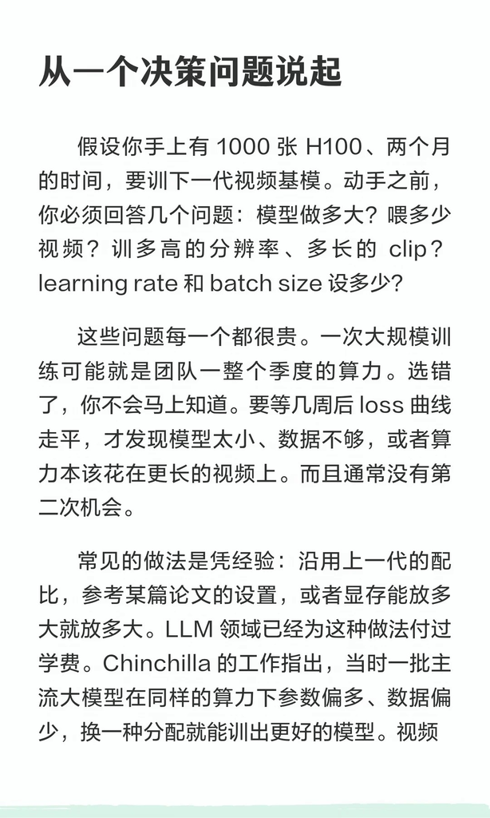

### 原图 03：研究目标与五类用途

<!-- source-number: 3; sha256: 0c0798088afce963571d3aad9b4e0d39f9466fa36feecd81db00283059c74505 -->

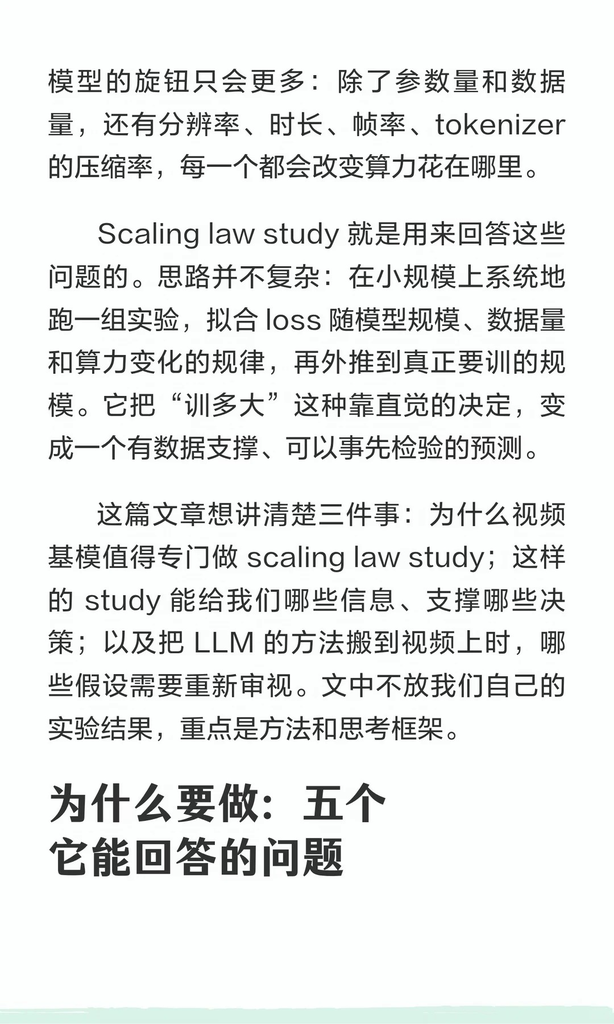

### 原图 04：算力分配与预测

<!-- source-number: 4; sha256: fe1eb346f456c15a23b742de840517d7ba2f6bd865e23dee394b0a149d5e1b40 -->

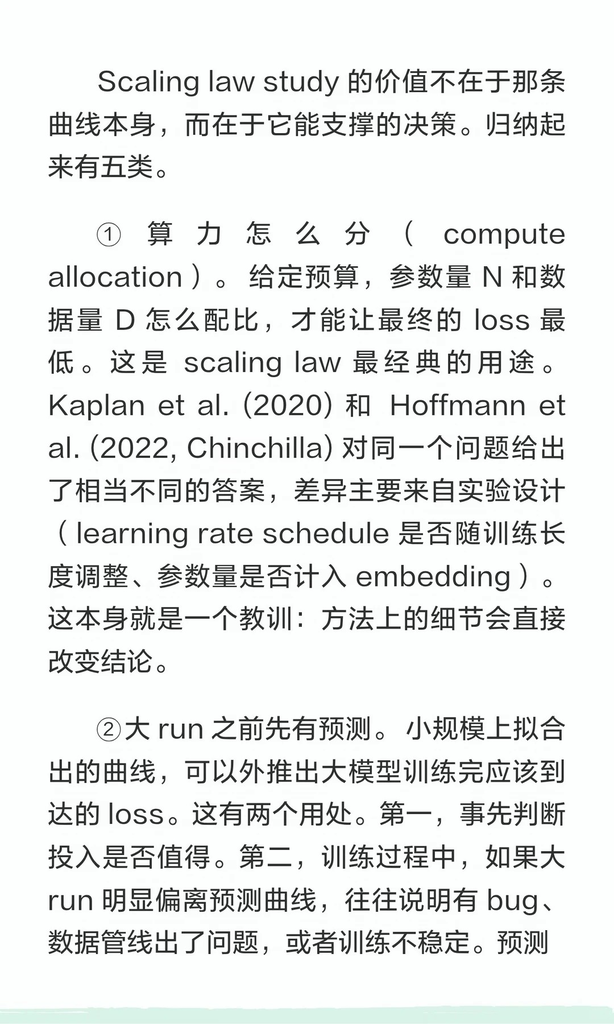

### 原图 05：方法比较与数据策略

<!-- source-number: 5; sha256: 402d4a1ece12013e54709e01a25ef09cb3daffc100a29e9b67e99fcdd08844ea -->

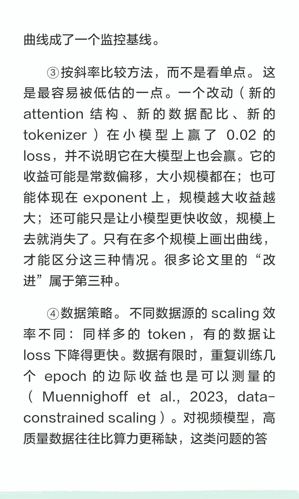

### 原图 06：超参数与视频假设

<!-- source-number: 6; sha256: ff793fc645fb4e7346a91b87d96cce035504f59c08e2bf8876eca72f685e5e1c -->

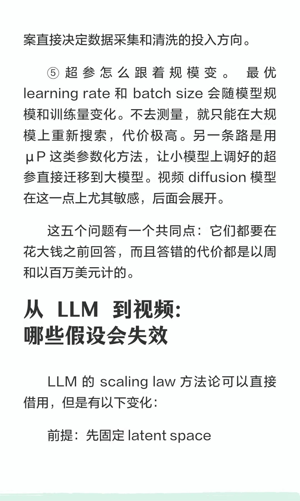

### 原图 07：固定 latent space 与数据单位

<!-- source-number: 7; sha256: 55564a1f6079c971e0c28d91b05e76bf5b33a61b4904b9225b09957447db2b3e -->

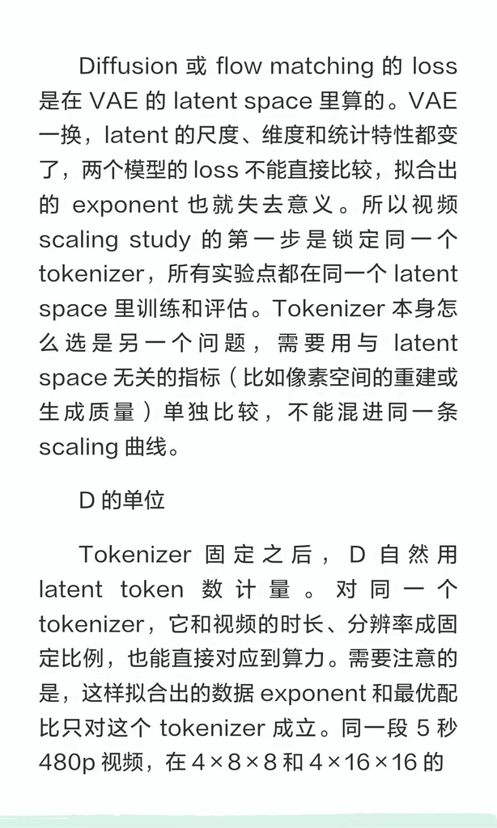

### 原图 08：噪声评估与 6ND

<!-- source-number: 8; sha256: 44b2d3e06043af2cd1adf1c1aaafb11d87ced6c1a17f9f2d9396d50a8c7d9cab -->

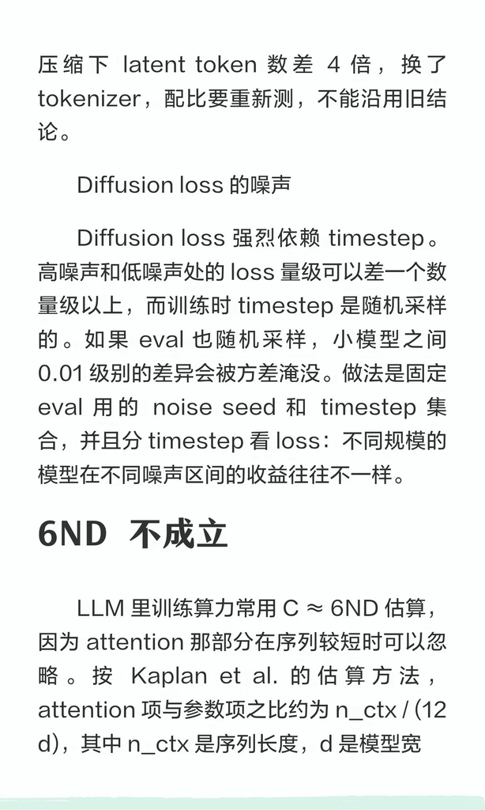

### 原图 09：长序列算力示例

<!-- source-number: 9; sha256: 8c13620c759638eeeae5c443451de276cf01fe8eef11656974ab97f5bf34ba3e -->

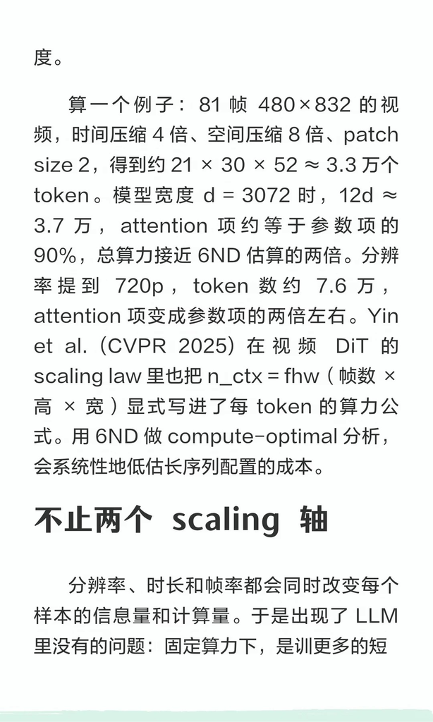

### 原图 10：时空轴与数据迁移

<!-- source-number: 10; sha256: 3b8e255248920d62476d7ad192a0c9640a50887b7f04c2bb0e3d0d5644636fdd -->

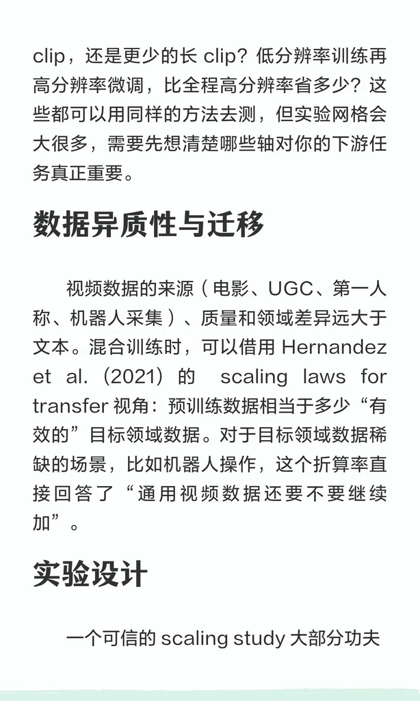

### 原图 11：实验网格设计

<!-- source-number: 11; sha256: 9b5de9a3cb5b171e8d07ec9f0f33337097428095af90eca8523c398ee7b14581 -->

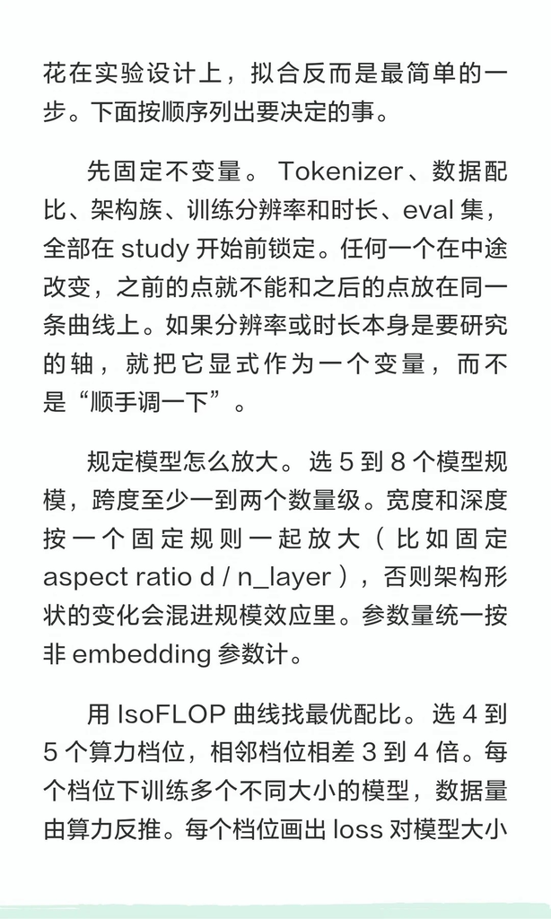

### 原图 12：IsoFLOP 与超参数

<!-- source-number: 12; sha256: cc7a91d164899938b7ca38215bd5e4eb39f0062b5a6fe81898dd41dea1ea672f -->

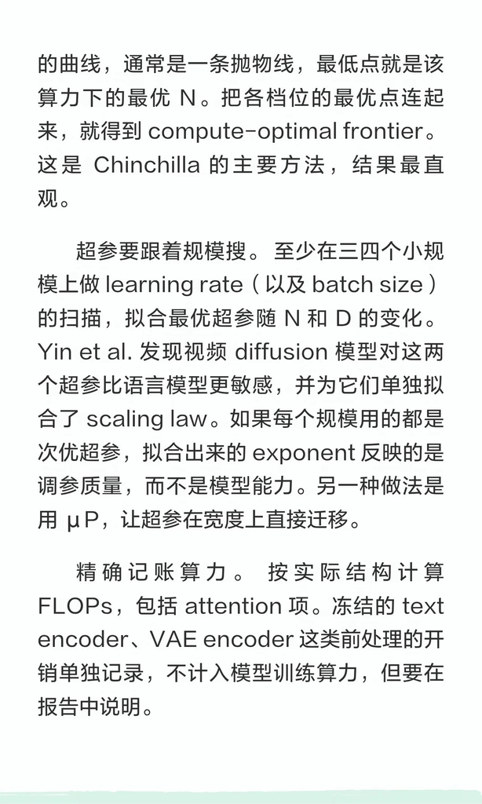

### 原图 13：验证协议与损失拟合

<!-- source-number: 13; sha256: a79bf3c403995f63b4624470ffddae100c5f841355d83c0ed799657a84c70364 -->

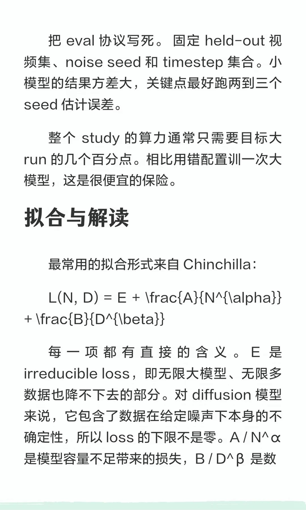

### 原图 14：最优配比推导

<!-- source-number: 14; sha256: d6679415dac2269b72fc56a68fc864de0e20df439abbcdaf7cc7500fdbddb242 -->

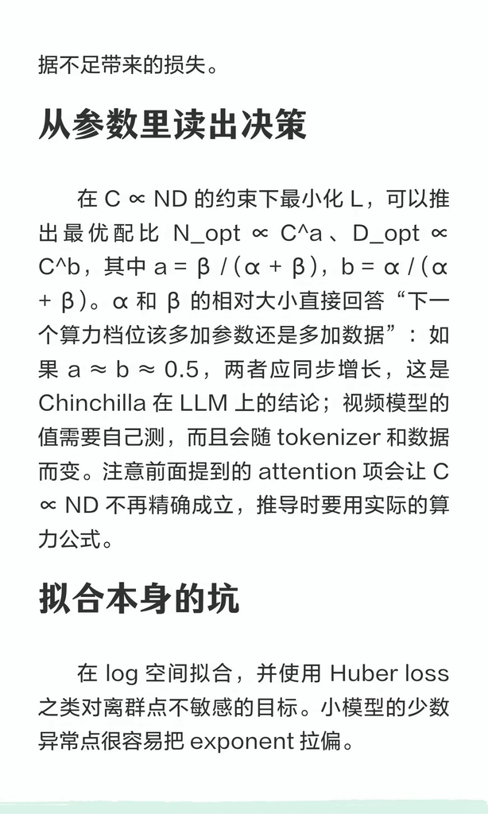

### 原图 15：不确定性与外推回测

<!-- source-number: 15; sha256: d2283a5b44e4d6806336ac021793a7b811f031831aab658b7aa92cc241a40d90 -->

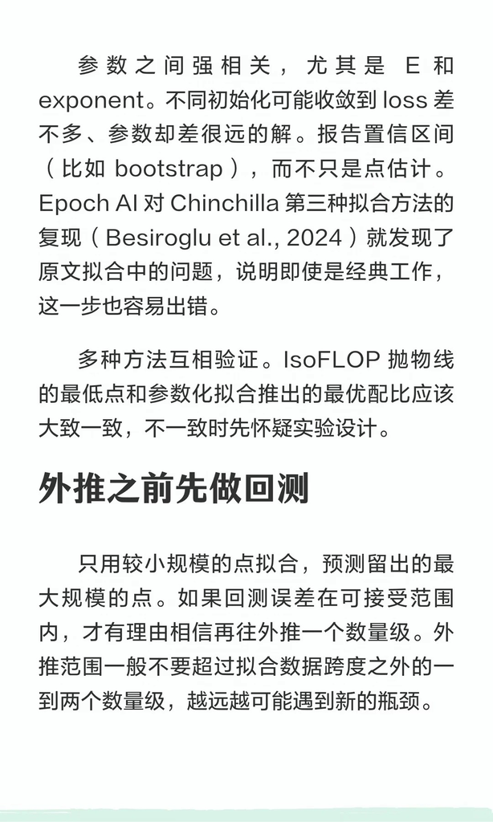

### 原图 16：方法比较与能力

<!-- source-number: 16; sha256: 20238c17c6cf46ca7584d75fb08cee27f84fb7c8feb6e669b46fffed721cc1c4 -->

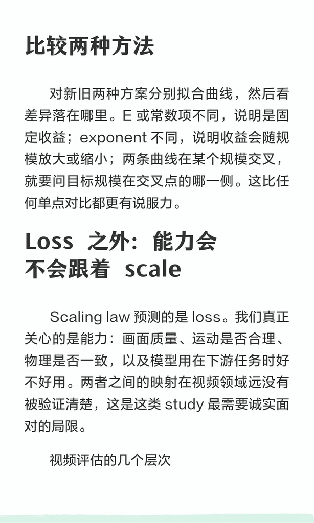

### 原图 17：视频评估层次

<!-- source-number: 17; sha256: 32520bc6084ac7e15024c40f9f71fef98b0ed41ceed004c7035c1cf783388f13 -->

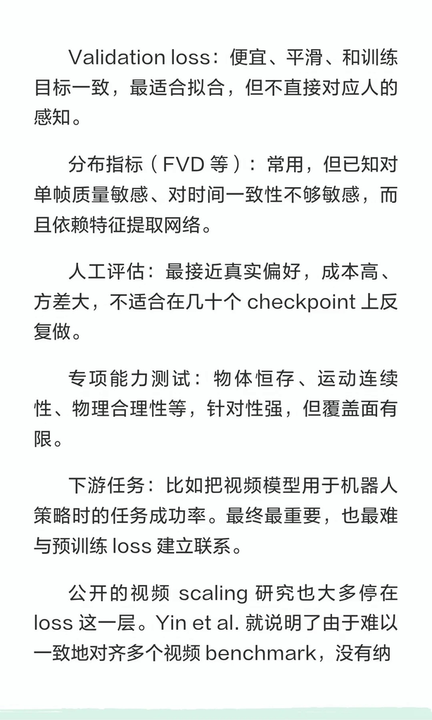

### 原图 18：代理指标与连续量

<!-- source-number: 18; sha256: eb2965a21dbd7256261c478f5ea232a787aef8e87b0d4e59c2a80e35fe374334 -->

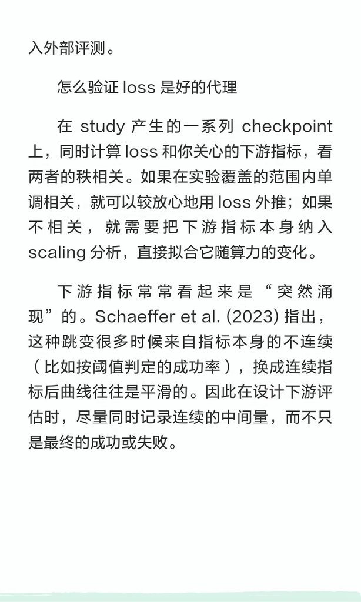

<!-- 以下为图片数据，请连同正文保留。 -->